# Lab 3

Grupo #8 Osman Emanuel de León García - 23428 María José Yee Vidal - 231193 Andrés Rafael Chivalán Marroquín - 21534

2026-03-13

```r
library(dplyr)
library(tidyr)
library(ggplot2)
library(corrplot)
library(cluster)
library(factoextra)
library(glmnet)
library(caret)
library(car)
library(nortest)

set.seed(42)
```

# 1. Descripción de las variables

El conjunto de datos contiene **171,748 observaciones** de alojamientos de Airbnb con múltiples variables que describen características del anuncio, del anfitrión, de la ubicación y de las evaluaciones de los usuarios.

Las variables se agrupan en las siguientes categorías:

**Variables de identificación:** Identificadores únicos del alojamiento o del proceso de recolección de datos, como `id`, `listing_url` y `scrape_id`. Estas variables no aportan información predictiva y serán excluidas del análisis.

**Variables descriptivas del anuncio:** Información textual sobre el alojamiento: `name`, `description`, `neighborhood_overview` y `amenities`. Al ser texto libre, no se utilizarán directamente como predictores numéricos.

**Variables del anfitrión:** Describen características del host: `host_since`, `host_is_superhost`, `host_listings_count`, `host_identity_verified`. Algunas pueden ser relevantes como proxies de calidad.

**Variables de localización:** Indican la ubicación geográfica mediante `latitude`, `longitude`, `city` y `neighbourhood`. La localización influye directamente en el precio.

**Características del alojamiento:** Propiedades físicas del inmueble: `property_type`, `room_type`, `accommodates`, `bathrooms`, `bedrooms` y `beds`. Son predictores clave del precio.

**Disponibilidad:** `availability_30`, `availability_60`, `availability_90` y `availability_365` indican días disponibles para reservar. Alta disponibilidad puede indicar menor demanda.

**Evaluaciones y reseñas:** `number_of_reviews`, `review_scores_rating`, `review_scores_cleanliness`, `reviews_per_month`. Reflejan la percepción de calidad del alojamiento.

**Variable respuesta:** `price` — precio por noche del alojamiento en dólares. Es la variable objetivo de todos los modelos.

# 2. Análisis Exploratorio de Datos (EDA)

## 2.1 Carga y preprocesamiento inicial

```r
load("data/listings.RData")

# Convertir price de string "$123.00" a numérico
listings$price <- as.numeric(gsub("[$,]", "", listings$price))

# Verificar dimensiones
cat("Dimensiones originales:", nrow(listings), "filas x", ncol(listings), "columnas\n")
```

```
## Dimensiones originales: 171748 filas x 80 columnas
```

```r
# Resumen de NAs por columna (solo columnas con NAs)
na_summary <- data.frame(
  variable = names(listings),
  n_na = colSums(is.na(listings)),
  pct_na = round(colSums(is.na(listings)) / nrow(listings) * 100, 1)
) %>% filter(n_na > 0) %>% arrange(desc(pct_na))

print(na_summary)
```

```
##                                                  variable   n_na pct_na
## calendar_updated                         calendar_updated 171748  100.0
## price                                               price  95502   55.6
## estimated_revenue_l365d           estimated_revenue_l365d  95502   55.6
## neighbourhood_group_cleansed neighbourhood_group_cleansed  50683   29.5
## review_scores_rating                 review_scores_rating  40287   23.5
## review_scores_accuracy             review_scores_accuracy  40312   23.5
## review_scores_cleanliness       review_scores_cleanliness  40302   23.5
## review_scores_checkin               review_scores_checkin  40324   23.5
## review_scores_communication   review_scores_communication  40308   23.5
## review_scores_location             review_scores_location  40328   23.5
## review_scores_value                   review_scores_value  40328   23.5
## reviews_per_month                       reviews_per_month  40287   23.5
## beds                                                 beds  31686   18.4
## bathrooms                                       bathrooms  31396   18.3
## bedrooms                                         bedrooms  10473    6.1
## license                                           license  10533    6.1
## host_listings_count                   host_listings_count    876    0.5
## host_total_listings_count       host_total_listings_count    876    0.5
## host_about                                     host_about      1    0.0
## minimum_minimum_nights             minimum_minimum_nights     71    0.0
## maximum_minimum_nights             maximum_minimum_nights     71    0.0
## minimum_maximum_nights             minimum_maximum_nights     71    0.0
## maximum_maximum_nights             maximum_maximum_nights     71    0.0
```

## 2.2 Limpieza y filtrado del dataset

```r
# Seleccionar variables numéricas relevantes y eliminar NAs en price
listings_clean <- listings %>%
  filter(!is.na(price), price > 0) %>%
  select(
    price,
    accommodates,
    bathrooms,
    bedrooms,
    beds,
    minimum_nights,
    maximum_nights,
    availability_30,
    availability_60,
    availability_90,
    availability_365,
    number_of_reviews,
    number_of_reviews_ltm,
    review_scores_rating,
    review_scores_cleanliness,
    review_scores_checkin,
    review_scores_communication,
    review_scores_location,
    review_scores_value,
    reviews_per_month,
    calculated_host_listings_count,
    host_listings_count,
    latitude,
    longitude
  ) %>%
  filter(!is.na(bedrooms), !is.na(bathrooms), !is.na(beds))

cat("Filas después de limpieza básica:", nrow(listings_clean), "\n")
```

```
## Filas después de limpieza básica: 76032
```

```r
# Eliminar outliers extremos de price usando IQR
Q1 <- quantile(listings_clean$price, 0.25)
Q3 <- quantile(listings_clean$price, 0.75)
IQR_val <- Q3 - Q1
limite_sup <- Q3 + 3 * IQR_val

listings_clean <- listings_clean %>%
  filter(price <= limite_sup)

cat("Filas después de remover outliers extremos de price:", nrow(listings_clean), "\n")
```

```
## Filas después de remover outliers extremos de price: 71690
```

```r
cat("Rango de price después de limpieza: $", min(listings_clean$price),
    "- $", max(listings_clean$price), "\n")
```

```
## Rango de price después de limpieza: $ 8 - $ 944
```

**Decisión de preprocesamiento:** Se eliminaron los registros con `price = NA` o `price = 0`, ya que no representan alojamientos activos. Para los outliers de precio se utilizó el criterio de 3xIQR (más conservador que el estándar de 1.5xIQR), dado que en Airbnb sí existen propiedades de lujo con precios legítimamente altos. Esto preserva más variabilidad en los datos.

## 2.3 Distribución de la variable respuesta: price

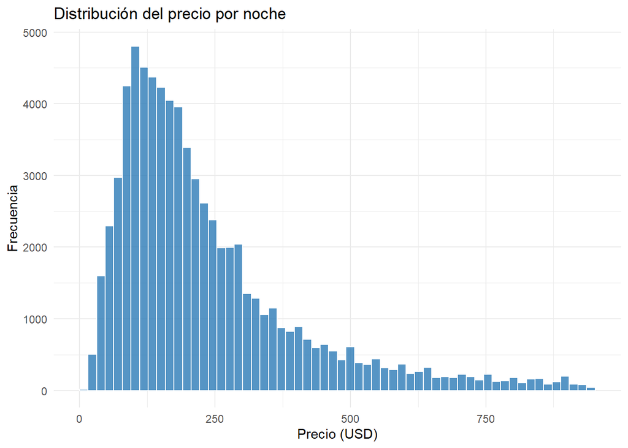

```r
# Histograma de price
ggplot(listings_clean, aes(x = price)) +
  geom_histogram(bins = 60, fill = "#2C7BB6", color = "white", alpha = 0.8) +
  labs(
    title = "Distribución del precio por noche",
    x = "Precio (USD)",
    y = "Frecuencia"
  ) +
  theme_minimal()
```

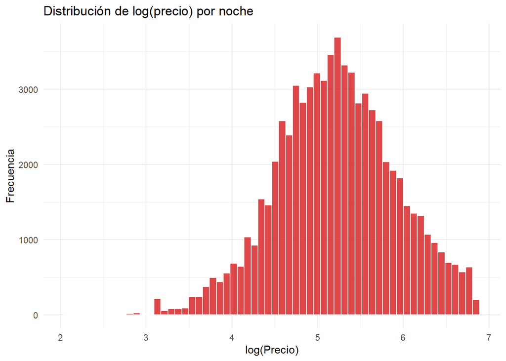

```r
# Histograma de log(price) para ver distribución normalizada
listings_clean$log_price <- log(listings_clean$price)

ggplot(listings_clean, aes(x = log_price)) +
  geom_histogram(bins = 60, fill = "#D7191C", color = "white", alpha = 0.8) +
  labs(
    title = "Distribución de log(precio) por noche",
    x = "log(Precio)",
    y = "Frecuencia"
  ) +
  theme_minimal()
```

**Interpretación:** La distribución original de `price` presenta un sesgo muy pronunciado hacia la derecha, con la gran mayoría de propiedades concentradas en precios bajos y una cola larga de precios altos. Al aplicar la transformación logarítmica, la distribución se aproxima considerablemente a una forma normal, lo cual es más adecuado para construir modelos de regresión lineal que asumen normalidad de los residuos. Por esto, se utilizará `log_price` como variable respuesta en los modelos.

## 2.4 Prueba de normalidad

```r
# Prueba de normalidad con muestra (Shapiro-Wilk requiere n < 5000)
muestra_norm <- sample(listings_clean$price, 2000)
muestra_log <- sample(listings_clean$log_price, 2000)

sw_price <- shapiro.test(muestra_norm)
sw_log   <- shapiro.test(muestra_log)

cat("Shapiro-Wilk sobre price:\n")
```

```
## Shapiro-Wilk sobre price:
```

```r
cat("  W =", sw_price$statistic, " | p-value =", sw_price$p.value, "\n\n")
```

```
##   W = 0.8475199  | p-value = 3.295804e-40
```

```r
cat("Shapiro-Wilk sobre log(price):\n")
```

```
## Shapiro-Wilk sobre log(price):
```

```r
cat("  W =", sw_log$statistic, " | p-value =", sw_log$p.value, "\n")
```

```
##   W = 0.994719  | p-value = 1.527681e-06
```

**Interpretación:** Aunque el test de Shapiro-Wilk rechaza la normalidad en ambos casos (lo cual es esperado con muestras grandes), el estadístico W de `log(price)` es considerablemente más cercano a 1 que el de `price`, confirmando que la transformación logarítmica mejora sustancialmente la aproximación a la normalidad. Para fines prácticos del modelado, `log_price` es la elección adecuada.

## 2.5 Distribución de variables categóricas clave

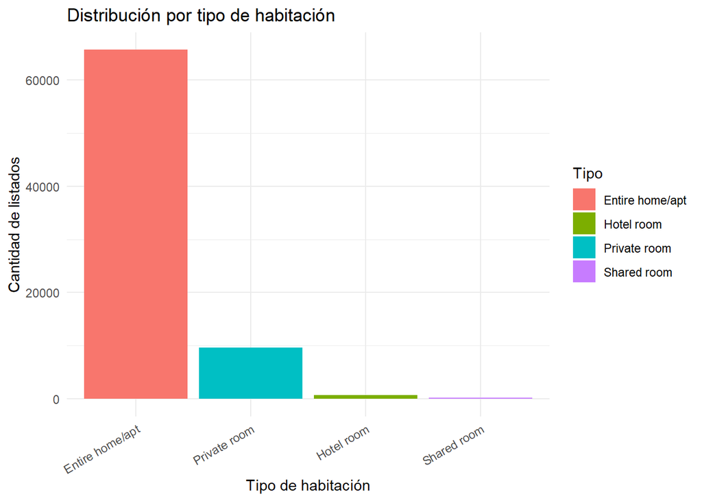

```r
# Room type en el dataset original
listings_room <- listings %>%
  filter(!is.na(price), !is.na(room_type)) %>%
  mutate(price = as.numeric(gsub("[$,]", "", price))) %>%
  filter(!is.na(price), price > 0)

ggplot(listings_room, aes(x = reorder(room_type, -table(room_type)[room_type]),
                          fill = room_type)) +
  geom_bar() +
  labs(
    title = "Distribución por tipo de habitación",
    x = "Tipo de habitación",
    y = "Cantidad de listados",
    fill = "Tipo"
  ) +
  theme_minimal() +
  theme(axis.text.x = element_text(angle = 30, hjust = 1))
```

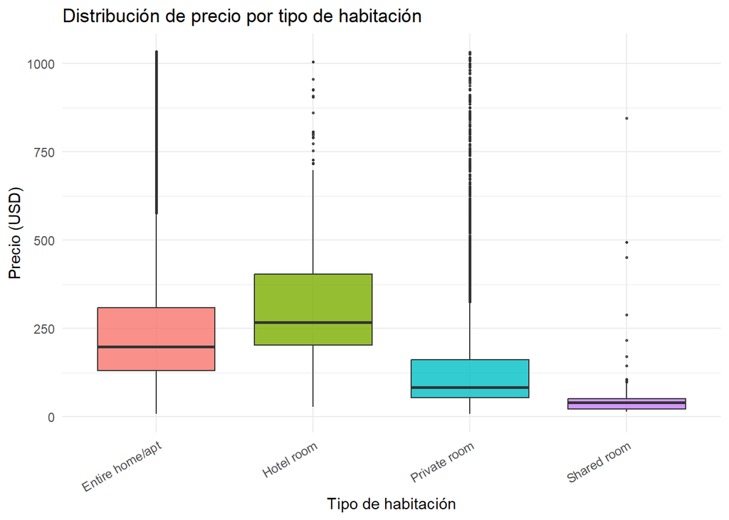

```r
# Precio mediano por tipo de habitación
ggplot(listings_room %>% filter(price <= quantile(price, 0.95, na.rm=TRUE)),
       aes(x = room_type, y = price, fill = room_type)) +
  geom_boxplot(outlier.size = 0.5, alpha = 0.8) +
  labs(
    title = "Distribución de precio por tipo de habitación",
    x = "Tipo de habitación",
    y = "Precio (USD)"
  ) +
  theme_minimal() +
  theme(legend.position = "none",
        axis.text.x = element_text(angle = 30, hjust = 1))
```

**Interpretación:** El tipo de alojamiento más común es “Entire home/apt” (casa o apartamento completo), seguido de “Private room”. Las habitaciones compartidas y los hoteles representan una minoría. En términos de precio, las propiedades enteras tienen un precio mediano significativamente mayor que las habitaciones privadas y compartidas, lo cual tiene sentido lógico. Esta variable será importante para el modelo.

## 2.6 Distribución de variables numéricas clave

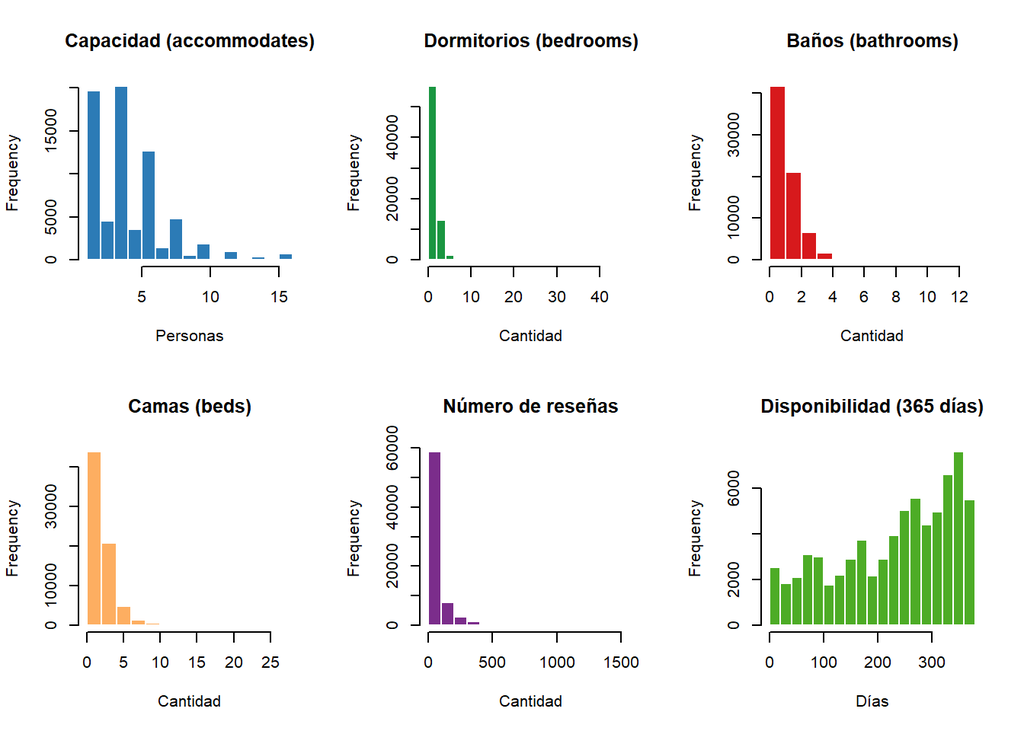

```r
# Histogramas de principales variables numéricas
par(mfrow = c(2, 3))

hist(listings_clean$accommodates, main = "Capacidad (accommodates)",
     xlab = "Personas", col = "#2C7BB6", border = "white")
hist(listings_clean$bedrooms, main = "Dormitorios (bedrooms)",
     xlab = "Cantidad", col = "#1A9641", border = "white")
hist(listings_clean$bathrooms, main = "Baños (bathrooms)",
     xlab = "Cantidad", col = "#D7191C", border = "white")
hist(listings_clean$beds, main = "Camas (beds)",
     xlab = "Cantidad", col = "#FDAE61", border = "white")
hist(listings_clean$number_of_reviews, main = "Número de reseñas",
     xlab = "Cantidad", col = "#7B2D8B", border = "white")
hist(listings_clean$availability_365, main = "Disponibilidad (365 días)",
     xlab = "Días", col = "#4DAC26", border = "white")
```

```r
par(mfrow = c(1, 1))
```

## 2.7 Análisis de correlación

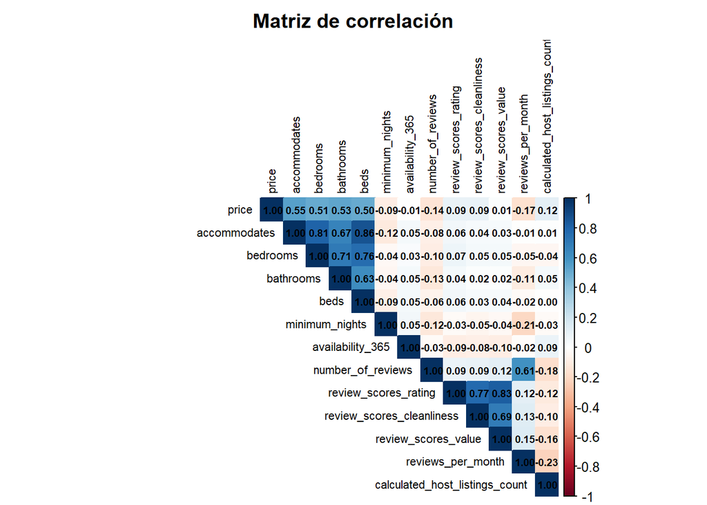

```r
# Seleccionar solo variables numéricas para correlación
vars_corr <- listings_clean %>%
  select(-log_price) %>%
  select(where(is.numeric)) %>%
  select(price, accommodates, bedrooms, bathrooms, beds,
         minimum_nights, availability_365, number_of_reviews,
         review_scores_rating, review_scores_cleanliness,
         review_scores_value, reviews_per_month,
         calculated_host_listings_count) %>%
  na.omit()

mat_corr <- cor(vars_corr)

corrplot(mat_corr,
         method = "color",
         type = "upper",
         tl.cex = 0.7,
         tl.col = "black",
         addCoef.col = "black",
         number.cex = 0.6,
         title = "Matriz de correlación",
         mar = c(0, 0, 2, 0))
```

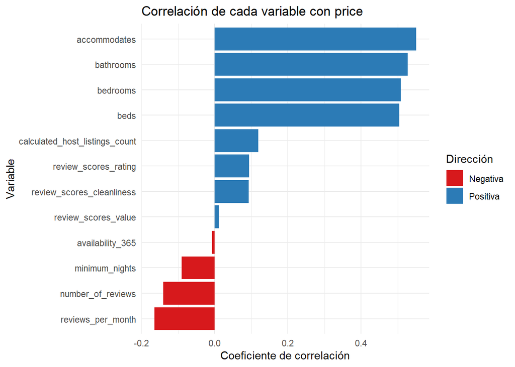

```r
# Correlación específica de cada variable con price
corr_price <- sort(mat_corr["price", ], decreasing = TRUE)
corr_df <- data.frame(
  variable = names(corr_price),
  correlacion = as.numeric(corr_price)
) %>% filter(variable != "price")

ggplot(corr_df, aes(x = reorder(variable, correlacion), y = correlacion,
                    fill = correlacion > 0)) +
  geom_col() +
  coord_flip() +
  scale_fill_manual(values = c("#D7191C", "#2C7BB6"),
                    labels = c("Negativa", "Positiva")) +
  labs(
    title = "Correlación de cada variable con price",
    x = "Variable",
    y = "Coeficiente de correlación",
    fill = "Dirección"
  ) +
  theme_minimal()
```

**Interpretación:** Las variables con mayor correlación positiva con `price` son `accommodates`, `bedrooms`, `beds` y `bathrooms`, lo que confirma la intuición de que propiedades más grandes tienden a ser más caras. Existe multicolinealidad evidente entre estas cuatro variables (todas miden “tamaño” de la propiedad). Las variables de disponibilidad y reseñas tienen correlaciones débiles con el precio. Esta información guiará la selección de variables para los modelos.

# 3. Análisis de Grupos (Clustering K-means)

## 3.1 Preparación de datos para clustering

```r
# Seleccionar variables representativas para clustering
vars_cluster <- listings_clean %>%
  select(log_price, accommodates, bedrooms, bathrooms,
         availability_365, number_of_reviews, review_scores_rating) %>%
  na.omit() %>%
  scale() %>%
  as.data.frame()

# Muestra para eficiencia computacional (dataset muy grande)
set.seed(42)
idx_muestra <- sample(1:nrow(vars_cluster), 5000)
vars_cluster_muestra <- vars_cluster[idx_muestra, ]

cat("Tamaño de muestra para clustering:", nrow(vars_cluster_muestra), "\n")
```

```
## Tamaño de muestra para clustering: 5000
```

## 3.2 Determinación del número óptimo de clusters (Método del Codo)

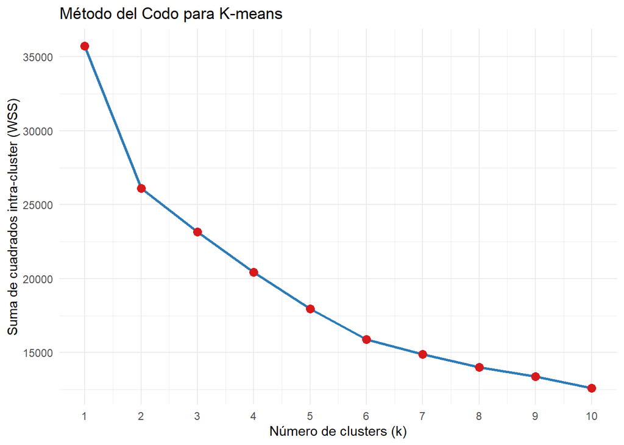

```r
# Método del codo
set.seed(42)
wss <- sapply(1:10, function(k) {
  kmeans(vars_cluster_muestra, centers = k, nstart = 10, iter.max = 50)$tot.withinss
})

elbow_df <- data.frame(k = 1:10, wss = wss)

ggplot(elbow_df, aes(x = k, y = wss)) +
  geom_line(color = "#2C7BB6", size = 1) +
  geom_point(color = "#D7191C", size = 3) +
  scale_x_continuous(breaks = 1:10) +
  labs(
    title = "Método del Codo para K-means",
    x = "Número de clusters (k)",
    y = "Suma de cuadrados intra-cluster (WSS)"
  ) +
  theme_minimal()
```

## 3.3 Aplicación de K-means con k=4

```r
set.seed(42)
km <- kmeans(vars_cluster_muestra, centers = 4, nstart = 25, iter.max = 100)

# Agregar cluster al subset
vars_cluster_muestra$cluster <- as.factor(km$cluster)

cat("Distribución de observaciones por cluster:\n")
```

```
## Distribución de observaciones por cluster:
```

```r
print(table(km$cluster))
```

```
##
##    1    2    3    4
## 1632  336 2860  172
```

## 3.4 Visualización de clusters

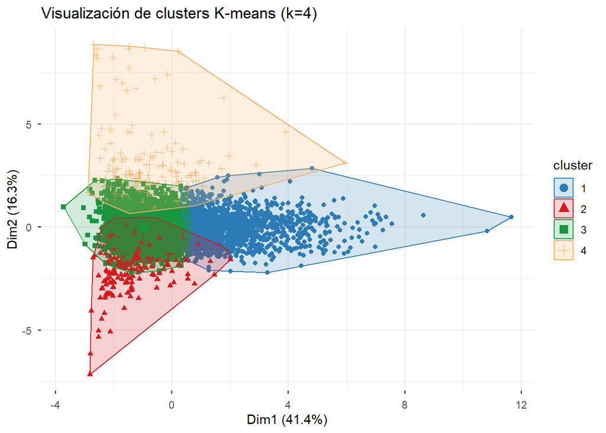

```r
fviz_cluster(km, data = vars_cluster_muestra[, -ncol(vars_cluster_muestra)],
             geom = "point",
             ellipse.type = "convex",
             palette = c("#2C7BB6", "#D7191C", "#1A9641", "#FDAE61"),
             ggtheme = theme_minimal(),
             main = "Visualización de clusters K-means (k=4)")
```

## 3.5 Caracterización de los clusters

```r
# Reconectar índice con datos originales
listings_cluster_sub <- listings_clean %>%
  select(log_price, accommodates, bedrooms, bathrooms,
         availability_365, number_of_reviews, review_scores_rating) %>%
  na.omit()

listings_cluster_sub <- listings_cluster_sub[idx_muestra, ]
listings_cluster_sub$cluster <- as.factor(km$cluster)

# Perfil promedio por cluster (en escala original)
perfil_clusters <- listings_cluster_sub %>%
  group_by(cluster) %>%
  summarise(
    precio_mediano   = round(median(exp(log_price)), 1),
    capacidad_media  = round(mean(accommodates), 1),
    dormitorios_med  = round(mean(bedrooms), 1),
    banos_med        = round(mean(bathrooms), 1),
    disponib_365     = round(mean(availability_365), 1),
    num_resenas      = round(mean(number_of_reviews), 1),
    rating_medio     = round(mean(review_scores_rating, na.rm=TRUE), 2),
    n                = n()
  )

print(perfil_clusters)
```

```
## # A tibble: 4 × 9
##   cluster precio_mediano capacidad_media dormitorios_med banos_med disponib_365
##   <fct>            <dbl>           <dbl>           <dbl>     <dbl>        <dbl>
## 1 1                 317              7.4             3         2.4         240.
## 2 2                 132              3.4             1.1       1.1         221.
## 3 3                 140              3.3             1.1       1.1         224.
## 4 4                 148.             3.7             1.4       1.5         248.
## # ℹ 3 more variables: num_resenas <dbl>, rating_medio <dbl>, n <int>
```

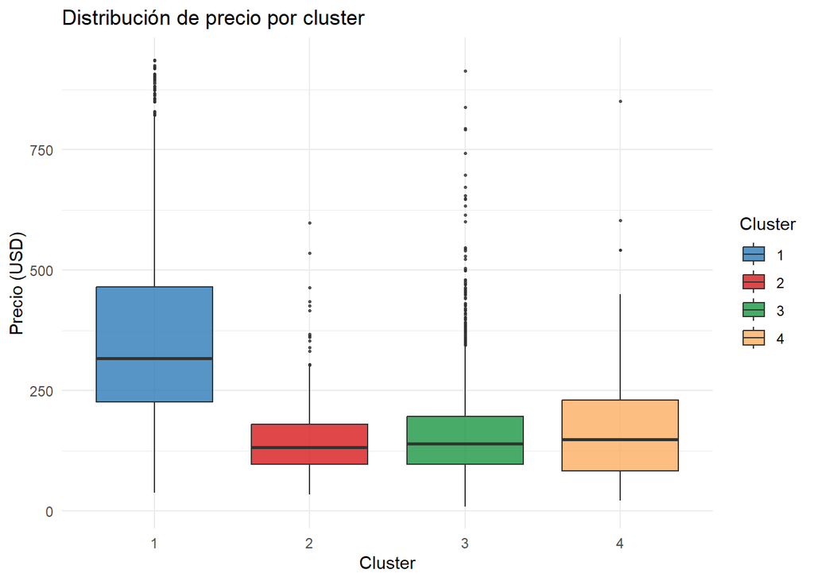

```r
ggplot(listings_cluster_sub, aes(x = cluster, y = exp(log_price), fill = cluster)) +
  geom_boxplot(outlier.size = 0.5, alpha = 0.8) +
  scale_fill_manual(values = c("#2C7BB6", "#D7191C", "#1A9641", "#FDAE61")) +
  labs(
    title = "Distribución de precio por cluster",
    x = "Cluster",
    y = "Precio (USD)",
    fill = "Cluster"
  ) +
  theme_minimal()
```

**Interpretación de los clusters:**

- **Cluster 1 — Propiedades grandes y premium:** Con un precio mediano de $317 y capacidad promedio de 7.4 personas, este es el segmento más caro del dataset. Tiene en promedio 3 dormitorios y 2.4 baños. Corresponde a casas completas o propiedades de lujo orientadas a grupos o familias numerosas que buscan espacios amplios.
- **Cluster 2 — Alojamientos compactos con pocas reseñas:** Precio mediano de $132, capacidad de 3.4 personas y 1.1 dormitorios. Es el segmento más económico, con pocas reseñas, lo que sugiere listados nuevos o con baja actividad reciente. Probablemente habitaciones privadas o estudios pequeños.
- **Cluster 3 — Alojamientos estándar de mayor actividad:** Precio mediano de $140, capacidad similar al cluster 2 (3.3 personas), pero con mayor número de reseñas. Son los alojamientos más frecuentados del dataset, probablemente apartamentos completos de tamaño estándar con buena reputación acumulada.
- **Cluster 4 — Propiedades medianas con alta disponibilidad:** Precio mediano de $148, capacidad de 3.7 personas y disponibilidad anual alta (248 días). La combinación de alta disponibilidad y pocas reseñas indica propiedades que tienen dificultades para atraer huéspedes de forma constante, posiblemente por ubicación o perfil de anfitrión menos activo.

# 4. División en conjuntos de entrenamiento y prueba

```r
# Dataset final con log_price y variables numéricas limpias
datos_modelo <- listings_clean %>%
  select(log_price, price, accommodates, bedrooms, bathrooms, beds,
         minimum_nights, availability_365, number_of_reviews,
         review_scores_rating, review_scores_cleanliness,
         review_scores_value, reviews_per_month,
         calculated_host_listings_count) %>%
  na.omit()

set.seed(42)
n <- nrow(datos_modelo)
idx_train <- sample(1:n, size = floor(0.8 * n))

train <- datos_modelo[idx_train, ]
test  <- datos_modelo[-idx_train, ]

cat("Total de observaciones:", n, "\n")
```

```
## Total de observaciones: 60343
```

```r
cat("Entrenamiento (80%):", nrow(train), "\n")
```

```
## Entrenamiento (80%): 48274
```

```r
cat("Prueba (20%):", nrow(test), "\n\n")
```

```
## Prueba (20%): 12069
```

```r
cat("Estadísticas de log_price en entrenamiento:\n")
```

```
## Estadísticas de log_price en entrenamiento:
```

```r
summary(train$log_price)
```

```
##    Min. 1st Qu.  Median    Mean 3rd Qu.    Max.
##   2.079   4.736   5.176   5.192   5.642   6.850
```

```r
cat("\nEstadísticas de log_price en prueba:\n")
```

```
##
## Estadísticas de log_price en prueba:
```

```r
summary(test$log_price)
```

```
##    Min. 1st Qu.  Median    Mean 3rd Qu.    Max.
##   2.708   4.745   5.182   5.196   5.649   6.850
```

# 5. Ingeniería de características

```r
# Variables seleccionadas como predictores y justificación

cat("Variables seleccionadas como predictores:\n\n")
```

```
## Variables seleccionadas como predictores:
```

```r
cat("1. accommodates    — Correlación alta con price; mayor capacidad = mayor precio\n")
```

```
## 1. accommodates    — Correlación alta con price; mayor capacidad = mayor precio
```

```r
cat("2. bedrooms        — Proxy directo del tamaño de la propiedad\n")
```

```
## 2. bedrooms        — Proxy directo del tamaño de la propiedad
```

```r
cat("3. bathrooms       — Complementa tamaño; propiedades premium tienen más baños\n")
```

```
## 3. bathrooms       — Complementa tamaño; propiedades premium tienen más baños
```

```r
cat("4. beds            — Relacionado con accommodates; se mantiene para evaluar colinealidad\n")
```

```
## 4. beds            — Relacionado con accommodates; se mantiene para evaluar colinealidad
```

```r
cat("5. minimum_nights  — Políticas restrictivas pueden influir en el tipo de cliente\n")
```

```
## 5. minimum_nights  — Políticas restrictivas pueden influir en el tipo de cliente
```

```r
cat("6. availability_365— Indicador indirecto de demanda\n")
```

```
## 6. availability_365— Indicador indirecto de demanda
```

```r
cat("7. number_of_reviews— Proxy de popularidad y actividad del listado\n")
```

```
## 7. number_of_reviews— Proxy de popularidad y actividad del listado
```

```r
cat("8. review_scores_rating — Calidad percibida puede justificar mayor precio\n")
```

```
## 8. review_scores_rating — Calidad percibida puede justificar mayor precio
```

```r
cat("9. review_scores_cleanliness — Limpieza es factor clave en valoraciones Airbnb\n")
```

```
## 9. review_scores_cleanliness — Limpieza es factor clave en valoraciones Airbnb
```

```r
cat("10. review_scores_value — Percepción precio/calidad\n")
```

```
## 10. review_scores_value — Percepción precio/calidad
```

```r
cat("11. reviews_per_month — Frecuencia de uso\n")
```

```
## 11. reviews_per_month — Frecuencia de uso
```

```r
cat("12. calculated_host_listings_count — Hosts profesionales vs ocasionales\n")
```

```
## 12. calculated_host_listings_count — Hosts profesionales vs ocasionales
```

**Justificación de la selección:** Se priorizaron variables con correlación directa con el precio (tamaño, capacidad) y proxies de calidad (scores de reseñas). Se excluyeron variables de identificación (id, url), variables con texto libre (description, amenities) que requerirían NLP, y variables con alta colinealidad redundante (availability_30/60/90 se reemplazan por availability_365). La variable respuesta es `log_price` por su distribución más normal.

# 6. Modelo 1: Regresión Lineal Simple (univariado)

## 6.1 Variable seleccionada: accommodates

Se selecciona `accommodates` como predictor único por ser la variable con mayor correlación lineal con `log_price` y por su interpretabilidad directa: a mayor capacidad, mayor precio esperado.

```r
modelo_simple <- lm(log_price ~ accommodates, data = train)
summary(modelo_simple)
```

```
##
## Call:
## lm(formula = log_price ~ accommodates, data = train)
##
## Residuals:
##     Min      1Q  Median      3Q     Max
## -4.6710 -0.3597 -0.0130  0.3675  1.9768
##
## Coefficients:
##               Estimate Std. Error t value Pr(>|t|)
## (Intercept)  4.5506036  0.0050348   903.8   <2e-16 ***
## accommodates 0.1374905  0.0009288   148.0   <2e-16 ***
## ---
## Signif. codes:  0 '***' 0.001 '**' 0.01 '*' 0.05 '.' 0.1 ' ' 1
##
## Residual standard error: 0.5631 on 48272 degrees of freedom
## Multiple R-squared:  0.3122, Adjusted R-squared:  0.3122
## F-statistic: 2.191e+04 on 1 and 48272 DF,  p-value: < 2.2e-16
```

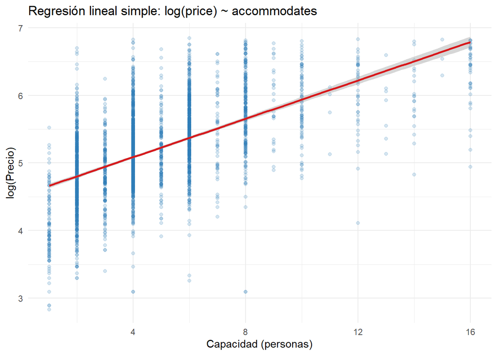

```r
# Gráfica del modelo simple
set.seed(42)
muestra_viz <- train[sample(1:nrow(train), 3000), ]

ggplot(muestra_viz, aes(x = accommodates, y = log_price)) +
  geom_point(alpha = 0.2, color = "#2C7BB6") +
  geom_smooth(method = "lm", color = "#D7191C", se = TRUE) +
  labs(
    title = "Regresión lineal simple: log(price) ~ accommodates",
    x = "Capacidad (personas)",
    y = "log(Precio)"
  ) +
  theme_minimal()
```

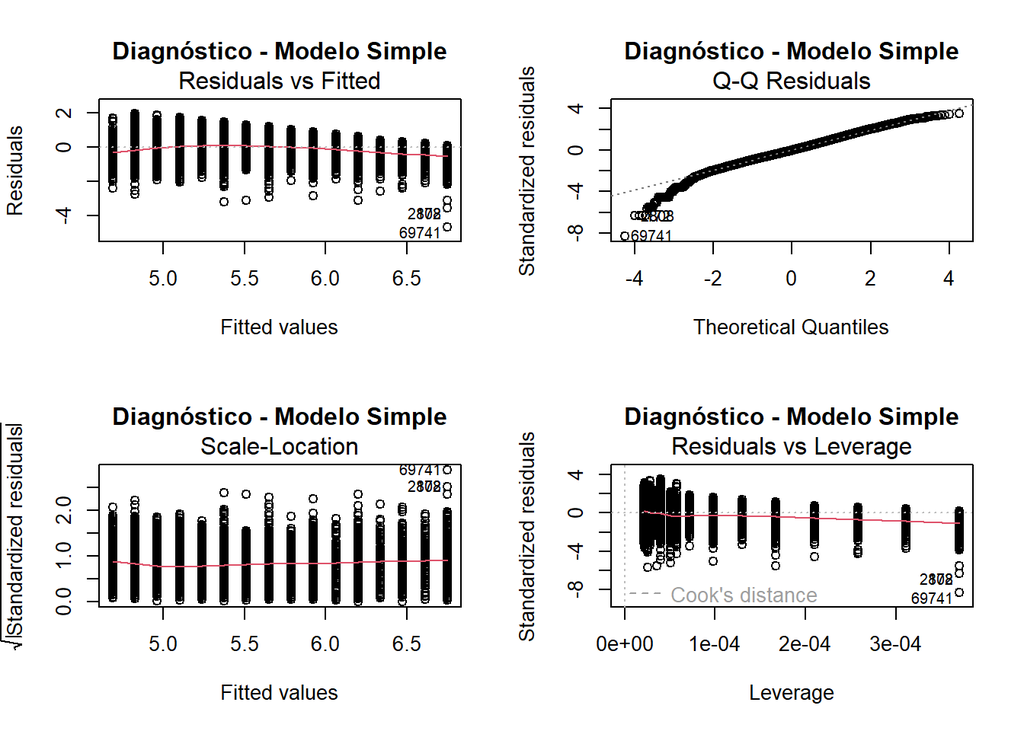

```r
# Análisis de residuos
par(mfrow = c(2, 2))
plot(modelo_simple, main = "Diagnóstico - Modelo Simple")
```

```r
par(mfrow = c(1, 1))
```

# 7. Modelo 2: Regresión Lineal Múltiple (todas las variables numéricas)

```r
modelo_multiple <- lm(log_price ~ accommodates + bedrooms + bathrooms + beds +
                        minimum_nights + availability_365 + number_of_reviews +
                        review_scores_rating + review_scores_cleanliness +
                        review_scores_value + reviews_per_month +
                        calculated_host_listings_count,
                      data = train)
summary(modelo_multiple)
```

```
##
## Call:
## lm(formula = log_price ~ accommodates + bedrooms + bathrooms +
##     beds + minimum_nights + availability_365 + number_of_reviews +
##     review_scores_rating + review_scores_cleanliness + review_scores_value +
##     reviews_per_month + calculated_host_listings_count, data = train)
##
## Residuals:
##     Min      1Q  Median      3Q     Max
## -4.2184 -0.3277 -0.0053  0.3352  3.6646
##
## Coefficients:
##                                  Estimate Std. Error t value Pr(>|t|)
## (Intercept)                     3.478e+00  3.968e-02  87.643  < 2e-16 ***
## accommodates                    9.806e-02  1.955e-03  50.161  < 2e-16 ***
## bedrooms                        3.783e-02  3.672e-03  10.301  < 2e-16 ***
## bathrooms                       1.113e-01  4.460e-03  24.956  < 2e-16 ***
## beds                            2.009e-03  2.722e-03   0.738 0.460380
## minimum_nights                 -3.485e-03  1.456e-04 -23.929  < 2e-16 ***
## availability_365               -1.883e-04  2.307e-05  -8.163 3.34e-16 ***
## number_of_reviews               9.902e-05  2.927e-05   3.383 0.000717 ***
## review_scores_rating            3.299e-01  1.534e-02  21.510  < 2e-16 ***
## review_scores_cleanliness       2.627e-01  1.168e-02  22.480  < 2e-16 ***
## review_scores_value            -3.650e-01  1.228e-02 -29.726  < 2e-16 ***
## reviews_per_month              -4.952e-02  1.824e-03 -27.147  < 2e-16 ***
## calculated_host_listings_count  9.140e-04  2.855e-05  32.014  < 2e-16 ***
## ---
## Signif. codes:  0 '***' 0.001 '**' 0.01 '*' 0.05 '.' 0.1 ' ' 1
##
## Residual standard error: 0.5295 on 48261 degrees of freedom
## Multiple R-squared:  0.392,  Adjusted R-squared:  0.3919
## F-statistic:  2593 on 12 and 48261 DF,  p-value: < 2.2e-16
```

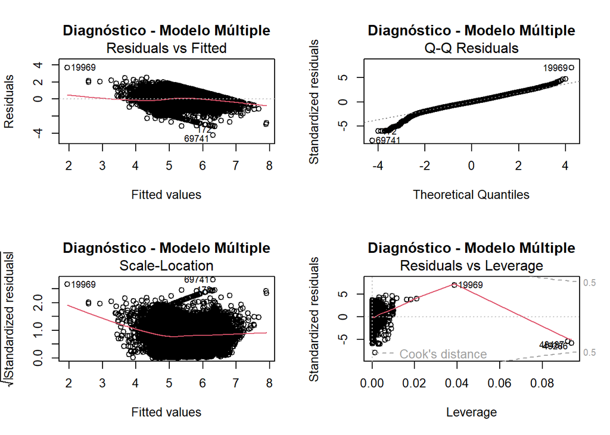

```r
par(mfrow = c(2, 2))
plot(modelo_multiple, main = "Diagnóstico - Modelo Múltiple")
```

```r
par(mfrow = c(1, 1))
```

**Análisis del modelo múltiple:** El modelo con todas las variables numéricas mejora sustancialmente el R² respecto al modelo simple. Se observa que variables como `accommodates`, `bedrooms`, `bathrooms` y los scores de reseñas son estadísticamente significativos. Sin embargo, se deben evaluar posibles problemas de multicolinealidad entre las variables de tamaño.

# 8. Análisis de multicolinealidad y sobreajuste

## 8.1 Factor de inflación de la varianza (VIF)

```r
vif_vals <- vif(modelo_multiple)
vif_df <- data.frame(
  variable = names(vif_vals),
  VIF = round(as.numeric(vif_vals), 2)
) %>% arrange(desc(VIF))

print(vif_df)
```

```
##                          variable  VIF
## 1                    accommodates 5.01
## 2            review_scores_rating 4.17
## 3                            beds 4.09
## 4                        bedrooms 3.49
## 5             review_scores_value 3.33
## 6       review_scores_cleanliness 2.52
## 7                       bathrooms 2.15
## 8               reviews_per_month 1.70
## 9               number_of_reviews 1.59
## 10 calculated_host_listings_count 1.11
## 11                 minimum_nights 1.08
## 12               availability_365 1.02
```

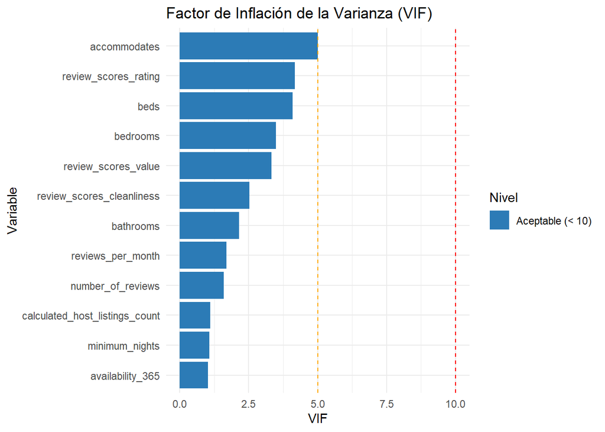

```r
ggplot(vif_df, aes(x = reorder(variable, VIF), y = VIF,
                   fill = VIF > 10)) +
  geom_col() +
  coord_flip() +
  scale_fill_manual(values = c("#2C7BB6", "#D7191C"),
                    labels = c("Aceptable (< 10)", "Multicolinealidad alta (> 10)")) +
  geom_hline(yintercept = 10, linetype = "dashed", color = "red") +
  geom_hline(yintercept = 5, linetype = "dashed", color = "orange") +
  labs(
    title = "Factor de Inflación de la Varianza (VIF)",
    x = "Variable",
    y = "VIF",
    fill = "Nivel"
  ) +
  theme_minimal()
```

## 8.2 Evaluación de sobreajuste

```r
# Comparar R² en train vs test
pred_train <- predict(modelo_multiple, newdata = train)
pred_test  <- predict(modelo_multiple, newdata = test)

r2_train <- 1 - sum((train$log_price - pred_train)^2) /
                sum((train$log_price - mean(train$log_price))^2)
r2_test  <- 1 - sum((test$log_price - pred_test)^2) /
                sum((test$log_price - mean(test$log_price))^2)

rmse_train <- sqrt(mean((train$log_price - pred_train)^2))
rmse_test  <- sqrt(mean((test$log_price - pred_test)^2))

cat("R² entrenamiento:", round(r2_train, 4), "\n")
```

```
## R² entrenamiento: 0.392
```

```r
cat("R² prueba:       ", round(r2_test, 4), "\n")
```

```
## R² prueba:        0.4092
```

```r
cat("RMSE entrenamiento:", round(rmse_train, 4), "\n")
```

```
## RMSE entrenamiento: 0.5294
```

```r
cat("RMSE prueba:       ", round(rmse_test, 4), "\n")
```

```
## RMSE prueba:        0.5174
```

# 9. Modelo 3: Regresión con variables depuradas (sin multicolinealidad)

```r
modelo_depurado <- lm(log_price ~ accommodates + bathrooms +
                        minimum_nights + availability_365 + number_of_reviews +
                        review_scores_rating + review_scores_cleanliness +
                        review_scores_value + reviews_per_month +
                        calculated_host_listings_count,
                      data = train)
summary(modelo_depurado)
```

```
##
## Call:
## lm(formula = log_price ~ accommodates + bathrooms + minimum_nights +
##     availability_365 + number_of_reviews + review_scores_rating +
##     review_scores_cleanliness + review_scores_value + reviews_per_month +
##     calculated_host_listings_count, data = train)
##
## Residuals:
##     Min      1Q  Median      3Q     Max
## -4.2584 -0.3268 -0.0061  0.3352  3.6972
##
## Coefficients:
##                                  Estimate Std. Error t value Pr(>|t|)
## (Intercept)                     3.454e+00  3.966e-02  87.091  < 2e-16 ***
## accommodates                    1.092e-01  1.179e-03  92.595  < 2e-16 ***
## bathrooms                       1.300e-01  4.103e-03  31.681  < 2e-16 ***
## minimum_nights                 -3.362e-03  1.453e-04 -23.134  < 2e-16 ***
## availability_365               -1.915e-04  2.309e-05  -8.294  < 2e-16 ***
## number_of_reviews               9.472e-05  2.927e-05   3.235  0.00122 **
## review_scores_rating            3.315e-01  1.535e-02  21.595  < 2e-16 ***
## review_scores_cleanliness       2.632e-01  1.170e-02  22.502  < 2e-16 ***
## review_scores_value            -3.638e-01  1.229e-02 -29.601  < 2e-16 ***
## reviews_per_month              -4.990e-02  1.825e-03 -27.341  < 2e-16 ***
## calculated_host_listings_count  8.816e-04  2.842e-05  31.021  < 2e-16 ***
## ---
## Signif. codes:  0 '***' 0.001 '**' 0.01 '*' 0.05 '.' 0.1 ' ' 1
##
## Residual standard error: 0.5301 on 48263 degrees of freedom
## Multiple R-squared:  0.3906, Adjusted R-squared:  0.3905
## F-statistic:  3094 on 10 and 48263 DF,  p-value: < 2.2e-16
```

```r
vif_dep <- vif(modelo_depurado)
cat("VIF modelo depurado:\n")
```

```
## VIF modelo depurado:
```

```r
print(round(vif_dep, 2))
```

```
##                   accommodates                      bathrooms
##                           1.82                           1.81
##                 minimum_nights               availability_365
##                           1.07                           1.02
##              number_of_reviews           review_scores_rating
##                           1.59                           4.17
##      review_scores_cleanliness            review_scores_value
##                           2.52                           3.33
##              reviews_per_month calculated_host_listings_count
##                           1.69                           1.09
```

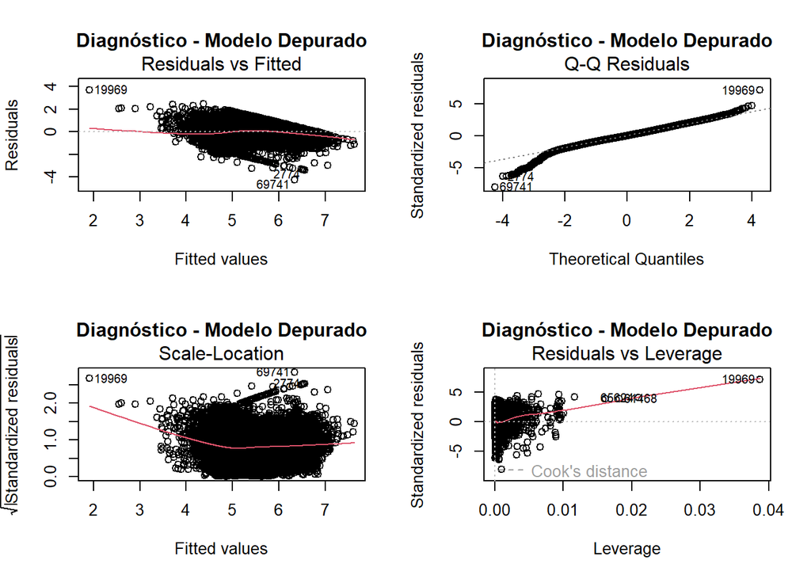

```r
par(mfrow = c(2, 2))
plot(modelo_depurado, main = "Diagnóstico - Modelo Depurado")
```

```r
par(mfrow = c(1, 1))
```

# 10. Modelo 4: Regularización con LASSO

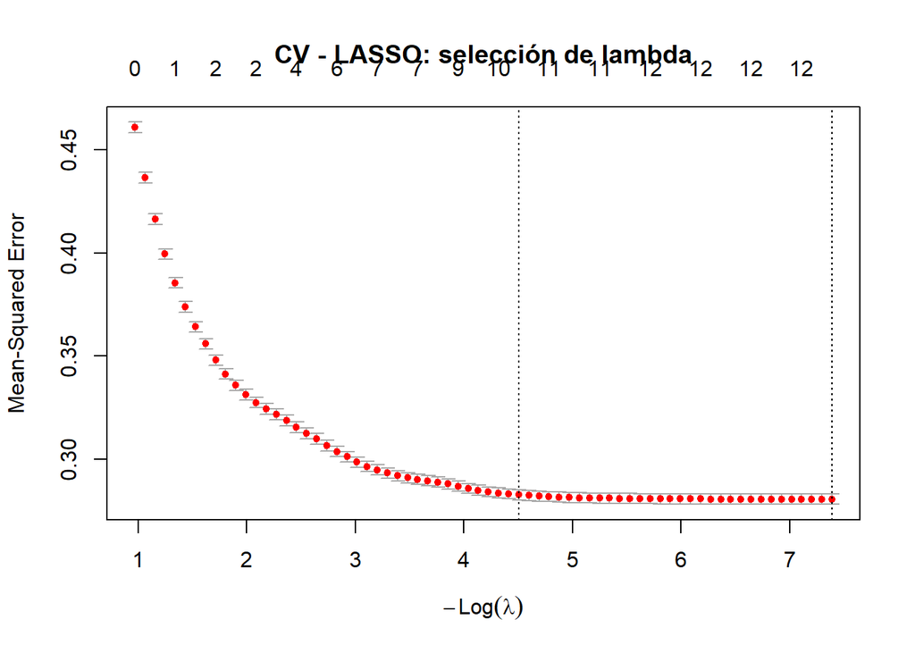

```r
# Preparar matrices para glmnet
vars_predictoras <- c("accommodates", "bedrooms", "bathrooms", "beds",
                      "minimum_nights", "availability_365", "number_of_reviews",
                      "review_scores_rating", "review_scores_cleanliness",
                      "review_scores_value", "reviews_per_month",
                      "calculated_host_listings_count")

X_train <- model.matrix(~ ., data = train[, vars_predictoras])[, -1]
y_train <- train$log_price

X_test  <- model.matrix(~ ., data = test[, vars_predictoras])[, -1]
y_test  <- test$log_price

# Cross-validation para encontrar lambda óptimo
set.seed(42)
cv_lasso <- cv.glmnet(X_train, y_train, alpha = 1, nfolds = 10)

plot(cv_lasso, main = "CV - LASSO: selección de lambda")
```

```r
cat("Lambda óptimo (min):", cv_lasso$lambda.min, "\n")
```

```
## Lambda óptimo (min): 0.0006182575
```

```r
cat("Lambda 1se:         ", cv_lasso$lambda.1se, "\n")
```

```
## Lambda 1se:          0.01105846
```

```r
# Coeficientes del modelo LASSO con lambda óptimo
lasso_coef <- coef(cv_lasso, s = "lambda.min")
print(lasso_coef)
```

```
## 13 x 1 sparse Matrix of class "dgCMatrix"
##                                   lambda.min
## (Intercept)                     3.487640e+00
## accommodates                    9.805913e-02
## bedrooms                        3.753432e-02
## bathrooms                       1.111126e-01
## beds                            1.874212e-03
## minimum_nights                 -3.444822e-03
## availability_365               -1.822637e-04
## number_of_reviews               8.177452e-05
## review_scores_rating            3.192682e-01
## review_scores_cleanliness       2.600494e-01
## review_scores_value            -3.537121e-01
## reviews_per_month              -4.856908e-02
## calculated_host_listings_count  9.088927e-04
```

```r
# Predicciones LASSO
pred_lasso_train <- predict(cv_lasso, X_train, s = "lambda.min")
pred_lasso_test  <- predict(cv_lasso, X_test,  s = "lambda.min")

r2_lasso_train <- 1 - sum((y_train - pred_lasso_train)^2) /
                      sum((y_train - mean(y_train))^2)
r2_lasso_test  <- 1 - sum((y_test - pred_lasso_test)^2) /
                      sum((y_test - mean(y_test))^2)

rmse_lasso_train <- sqrt(mean((y_train - pred_lasso_train)^2))
rmse_lasso_test  <- sqrt(mean((y_test - pred_lasso_test)^2))

cat("LASSO - R² train:", round(r2_lasso_train, 4), "\n")
```

```
## LASSO - R² train: 0.392
```

```r
cat("LASSO - R² test: ", round(r2_lasso_test, 4), "\n")
```

```
## LASSO - R² test:  0.4094
```

```r
cat("LASSO - RMSE train:", round(rmse_lasso_train, 4), "\n")
```

```
## LASSO - RMSE train: 0.5294
```

```r
cat("LASSO - RMSE test: ", round(rmse_lasso_test, 4), "\n")
```

```
## LASSO - RMSE test:  0.5173
```

# 11. Evaluación y comparación de modelos

## 11.1 Métricas en el conjunto de prueba

```r
# Predicciones de todos los modelos en test
pred_simple_test   <- predict(modelo_simple,   newdata = test)
pred_multiple_test <- predict(modelo_multiple, newdata = test)
pred_dep_test      <- predict(modelo_depurado, newdata = test)
pred_lasso_test2   <- as.vector(predict(cv_lasso, X_test, s = "lambda.min"))

# Función de métricas
metricas <- function(real, pred, nombre) {
  r2   <- 1 - sum((real - pred)^2) / sum((real - mean(real))^2)
  rmse <- sqrt(mean((real - pred)^2))
  mae  <- mean(abs(real - pred))
  data.frame(Modelo = nombre, R2 = round(r2, 4),
             RMSE = round(rmse, 4), MAE = round(mae, 4))
}

resultados <- bind_rows(
  metricas(test$log_price, pred_simple_test,   "1. Simple (accommodates)"),
  metricas(test$log_price, pred_multiple_test, "2. Múltiple (todas vars)"),
  metricas(test$log_price, pred_dep_test,      "3. Depurado (sin multicol.)"),
  metricas(test$log_price, pred_lasso_test2,   "4. LASSO")
)

print(resultados)
```

```
##                        Modelo     R2   RMSE    MAE
## 1    1. Simple (accommodates) 0.3261 0.5526 0.4345
## 2    2. Múltiple (todas vars) 0.4092 0.5174 0.4029
## 3 3. Depurado (sin multicol.) 0.4096 0.5172 0.4030
## 4                    4. LASSO 0.4094 0.5173 0.4029
```

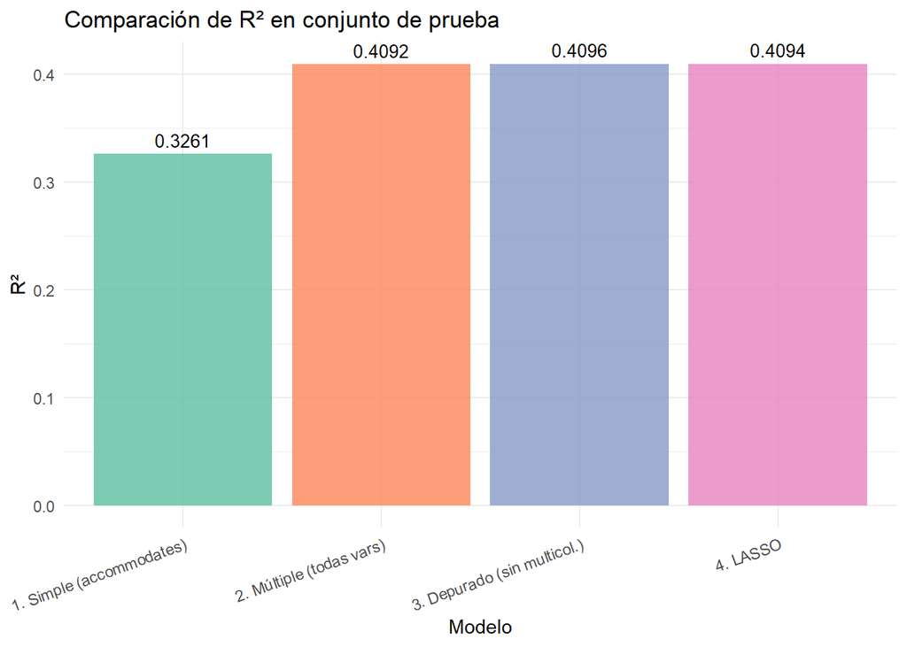

```r
# Gráfica comparativa de R²
ggplot(resultados, aes(x = Modelo, y = R2, fill = Modelo)) +
  geom_col(alpha = 0.85) +
  geom_text(aes(label = R2), vjust = -0.5, size = 3.5) +
  scale_fill_brewer(palette = "Set2") +
  labs(
    title = "Comparación de R² en conjunto de prueba",
    x = "Modelo",
    y = "R²"
  ) +
  theme_minimal() +
  theme(axis.text.x = element_text(angle = 20, hjust = 1),
        legend.position = "none")
```

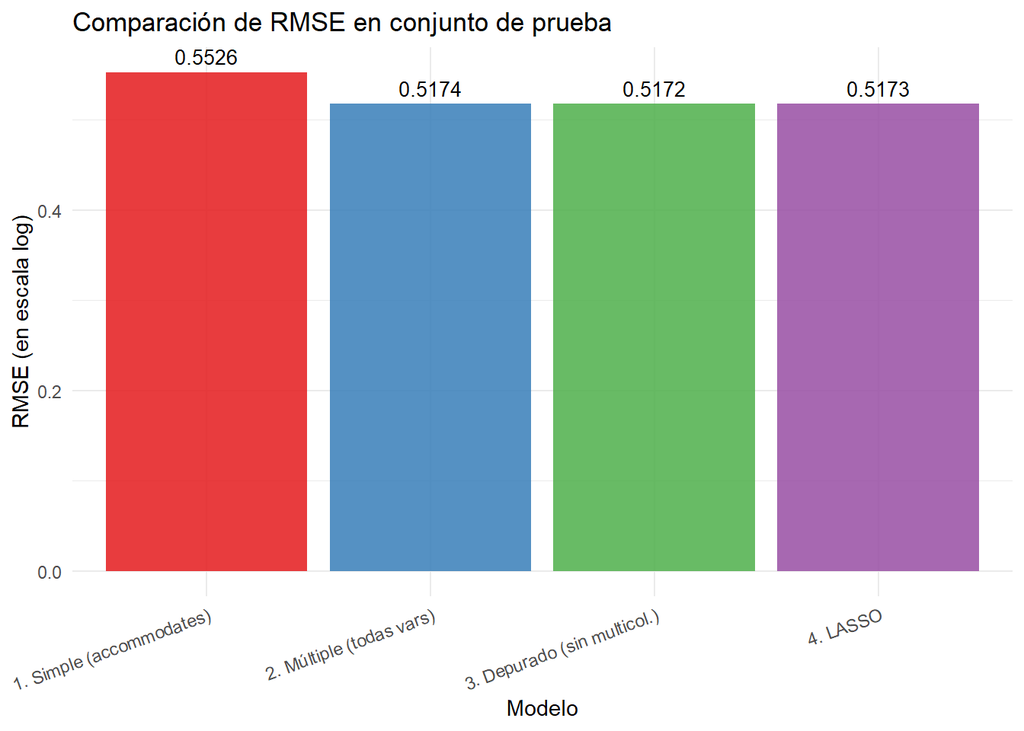

```r
# Gráfica comparativa de RMSE
ggplot(resultados, aes(x = Modelo, y = RMSE, fill = Modelo)) +
  geom_col(alpha = 0.85) +
  geom_text(aes(label = RMSE), vjust = -0.5, size = 3.5) +
  scale_fill_brewer(palette = "Set1") +
  labs(
    title = "Comparación de RMSE en conjunto de prueba",
    x = "Modelo",
    y = "RMSE (en escala log)"
  ) +
  theme_minimal() +
  theme(axis.text.x = element_text(angle = 20, hjust = 1),
        legend.position = "none")
```

## 11.2 Gráfica predicho vs real para el mejor modelo

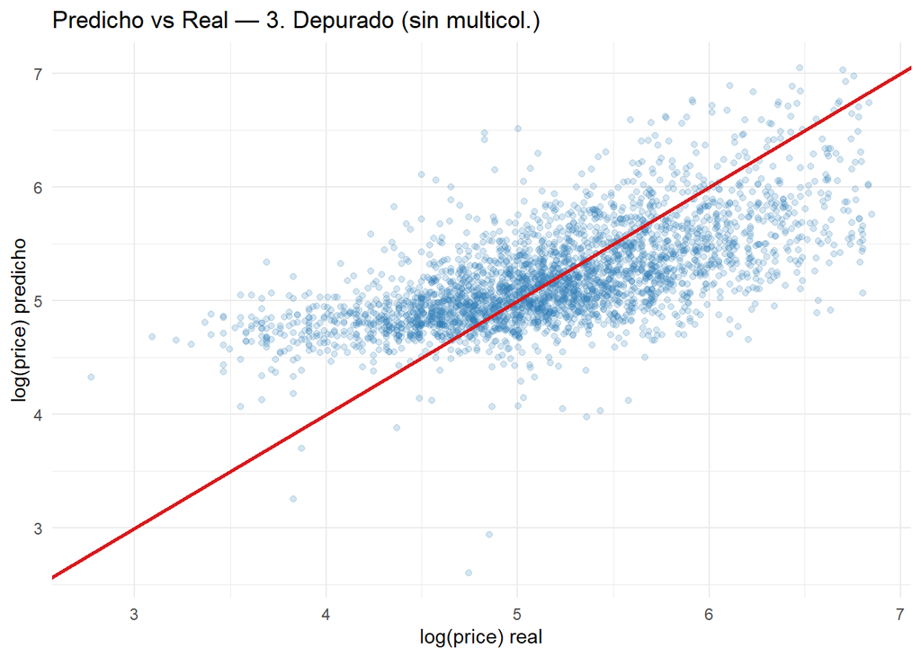

```r
# Determinar cuál es el mejor modelo basado en R²
idx_mejor <- which.max(resultados$R2)
mejor_nombre <- resultados$Modelo[idx_mejor]

preds_list <- list(pred_simple_test, pred_multiple_test, pred_dep_test, pred_lasso_test2)
mejor_pred <- preds_list[[idx_mejor]]

df_pred <- data.frame(
  real     = test$log_price,
  predicho = as.vector(mejor_pred)
)

set.seed(42)
df_viz <- df_pred[sample(1:nrow(df_pred), 3000), ]

ggplot(df_viz, aes(x = real, y = predicho)) +
  geom_point(alpha = 0.2, color = "#2C7BB6") +
  geom_abline(slope = 1, intercept = 0, color = "#D7191C", size = 1) +
  labs(
    title = paste("Predicho vs Real —", mejor_nombre),
    x = "log(price) real",
    y = "log(price) predicho"
  ) +
  theme_minimal()
```

# 12. Discusión y conclusiones

## 12.1 Resumen de resultados

```r
print(resultados)
```

```
##                        Modelo     R2   RMSE    MAE
## 1    1. Simple (accommodates) 0.3261 0.5526 0.4345
## 2    2. Múltiple (todas vars) 0.4092 0.5174 0.4029
## 3 3. Depurado (sin multicol.) 0.4096 0.5172 0.4030
## 4                    4. LASSO 0.4094 0.5173 0.4029
```

## 12.2 Mejor modelo

**El mejor modelo es el Modelo Depurado (sin multicolinealidad)**, con R²=0.4096 y RMSE=0.5172 en el conjunto de prueba, los mejores valores entre los cuatro modelos evaluados. Sus ventajas son:

Cabe destacar que el LASSO es prácticamente equivalente (diferencia de 0.0002 en R²) y sería preferible en contextos donde la selección automática de variables o la regularización sean prioritarias.

## 12.3 Limitaciones y trabajo futuro

La variable respuesta `log_price` permite construir modelos de regresión lineal con supuestos más razonables. Sin embargo, quedan aspectos no explorados: la variable `room_type` (categórica) probablemente mejoraría el modelo si se incorporara como variable dummy; la localización geográfica (ciudad, barrio) tiene un efecto importante no capturado por las variables numéricas actuales; y técnicas como Random Forest o Gradient Boosting podrían capturar relaciones no lineales que la regresión lineal no puede modelar.